# DS 624: Homwork 3 (TS Decomposition)

Hyndman: 6.2, 6.3

Donny Lofland

# DS624 Homework 3

## Problem 6.2

The plastics data set consists of the monthly sales (in thousands) of product A for a plastics manufacturer for five years.

1. Plot the time series of sales of product A. Can you identify seasonal fluctuations and/or a trend-cycle?

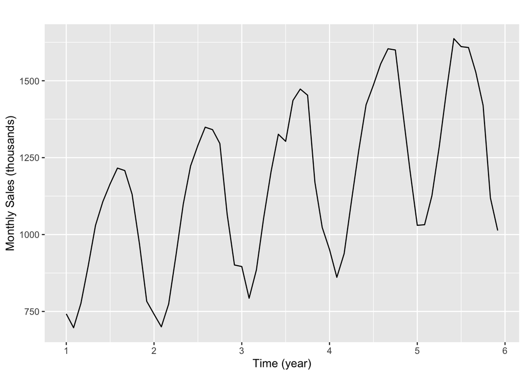

```r
autoplot(plastics, xlab="Time (year)", ylab = 'Monthly Sales (thousands)')
```

> Overall there is a yearly cycle with the peak ~Q3 and the trough at ~Jan/Feb after christmas. Overall there is an increasing trend in sales, so business must bee good :)
2. Use a classical multiplicative decomposition to calculate the trend-cycle and seasonal indices.

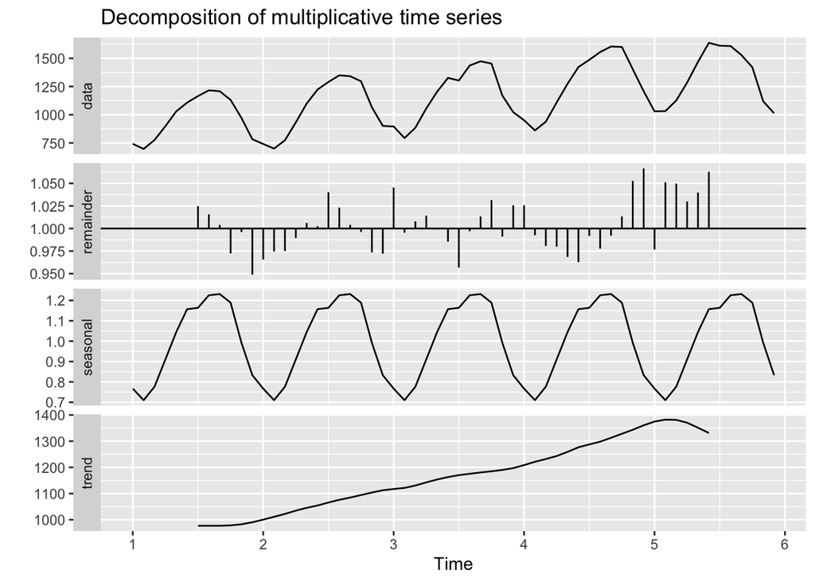

```r
fit <- plastics %>% decompose(type='multiplicative')

autoplot(fit)
```

3. Do the results support the graphical interpretation from part a?

> Yes, the trend is now mesurable and the seasonal pattern mathes the visual inspection from part A (ie yearly cycles). Note that the residuals show a cyclic pattern suggesting that there is additional variability not captured by trend or seasons. This may be year of year variability, but it shows cyclic patterns suggesting a more robust decomposition might be necessary.
4. Compute and plot the seasonally adjusted data.

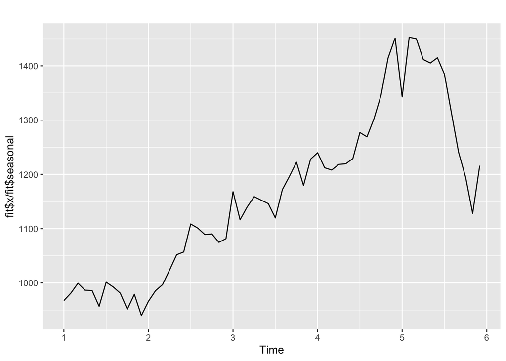

```r
autoplot(fit$x / fit$seasonal)
```

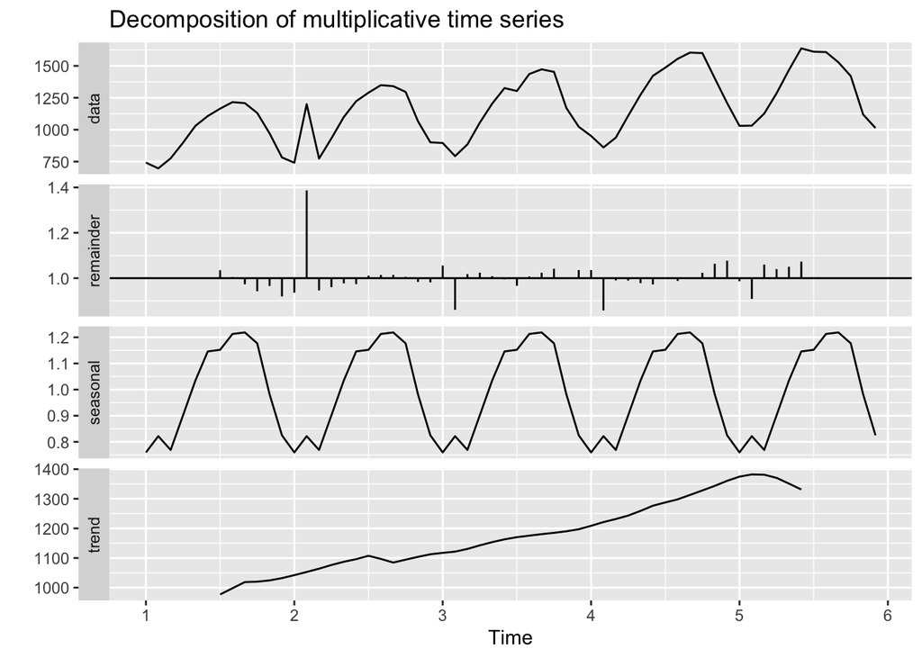

```r
plastics2 <- plastics
plastics2[14] <- plastics2[14] + 500

fit2 <- plastics2 %>% decompose(type='multiplicative')

autoplot(fit2)
```